# Eye on the Storm: A Journey Through Storm Trajectories

Nicole Rodriguez

04/17/25

# Introduction

This project explores the paths and intensities of major storms in the Atlantic using a combination of static and interactive visualizations. By leveraging R packages like **mapview()**, dynamic maps were created to visualize storm tracks, colored by attributes like *year* and *wind speed*. The interactive plots not only allow users to explore storm paths geographically, but also identify individual storms by clicking on their tracks.

The data comes from the **storms** dataset available in the R package **dplyr**, which provides detailed information on storm names, tracks, wind speeds, and more. This dataset is important because it captures some of the most impactful storms, including Maria, Irma, Katrina, and Sandy. The visualizations provide valuable insight into the potential effects of climate change on the frequency and strength of hurricanes, an increasingly critical area of research.

# Data

## Load Libraries and Packages

```r
# Load any R Packages
if (!require("mosaic"))
  install.packages("mosaic")
if (!require("tidyverse"))
  install.packages("tidyverse")
if (!require("ggplot2"))
  install.packages("ggplot2")
if (!require("dplyr"))
  install.packages("dplyr")
if (!require("sf"))
  install.packages("sf")
if (!require("mapview"))
  install.packages("mapview")
if (!require("leafpop"))
  install.packages("leafpop")

library(mosaic) # Stats analysis
library(tidyverse) # Data manipulation & visualization
library(ggplot2) # Data visualization
library(dplyr) # Data manipulation
library(sf) # Simple features in R
library(mapview) # Interactive view
library(leafpop) # Popups with tables
```

## Description of Data

The storms dataset, available in the `dplyr` package, includes 13 variables and 19,537 observations including the position and attributes of storms from 1975-2022. This dataset offers valuable records of storm behavior over time, making it ideal for exploring patterns in storm paths, intensity. and how they may be changing over time. This is an important topic in the context of climate change and preparations for disasters.

> R Package: `dplyr`

> Data set: `storms`

## Load & Filter Data

```r
# Load the storms dataset
storm_names <- dplyr::storms

# Remove storms with names starting with "AL0" or "Al2"
storm_names <- filter(storm_names, !grepl('AL0*', name) & !grepl('Al2*', name))

# Select wind, status, and name columns
storm_names <- storm_names %>%
  select(wind, status, name)
```

From the 216 hurricanes in this data set, we will be analyzing the top 6 well-known and most catastrophic hurricanes.

> The six hurricanes featured in this analysis are:
- **Sandy**
- **Irma**
- **Andrew**
- **Maria**
- **Harvey**
- **Katrina**

```r
# Load Data
storms_data <- dplyr::storms

# Filter storms
storms_data <- filter(storms_data, name == "Sandy" | name == "Irma" | name == "Andrew" | name == "Maria" | name == "Harvey" | name == "Katrina")

# Filter the storms_data dataset to include only tropical depressions, tropical storms, and hurricanes
storms_data <- filter(storms_data, status == "tropical depression" | status == "tropical storm" | status == "hurricane")

# Summary stats of wind by storm name
favstats(wind ~ name, data = storms_data)
```

| name | min | Q1 | median | Q3 | max | mean | sd | n | missing |
| --- | --- | --- | --- | --- | --- | --- | --- | --- | --- |
| Andrew | 20 | 40.00 | 45 | 115.00 | 150 | 68.04688 | 40.66527 | 64 | 0 |
| Harvey | 20 | 35.00 | 45 | 55.00 | 115 | 49.82993 | 22.00105 | 147 | 0 |
| Irma | 30 | 91.25 | 100 | 140.00 | 155 | 104.60938 | 38.06119 | 64 | 0 |
| Katrina | 20 | 30.00 | 40 | 71.25 | 150 | 55.88235 | 34.04279 | 68 | 0 |
| Maria | 30 | 50.00 | 65 | 83.75 | 150 | 69.25373 | 28.82086 | 134 | 0 |
| Sandy | 30 | 60.00 | 65 | 80.00 | 100 | 67.72727 | 18.41751 | 33 | 0 |

# Data Analysis

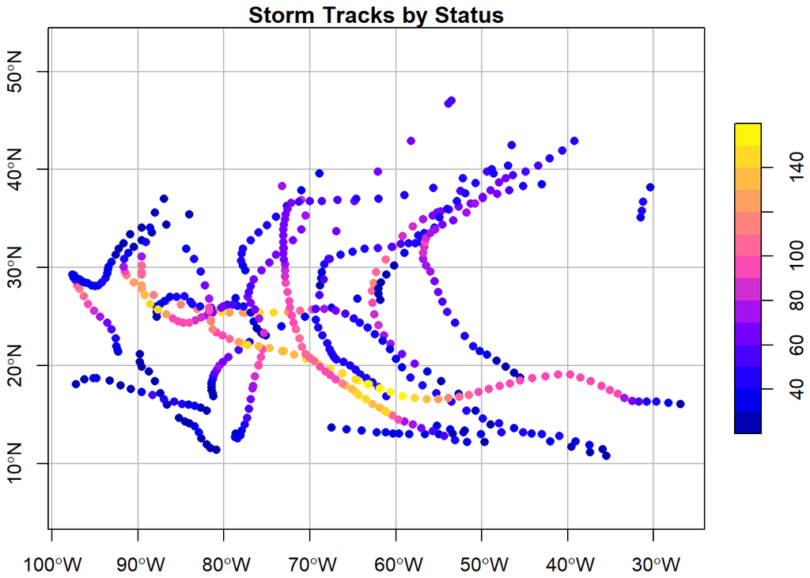

```r
# Base R Plot mapping storms by storm status
plot(storms_data.sf["wind"],
     type = 'p', # Point plot
     cex = 1, # Point size
     pch = 16, # Point shape
     axes = TRUE, # Show axes
     graticule = TRUE, # Grid lines
     main = "Storm Tracks by Status",
     xlab = "Longitude", # X-axis label
     ylab = "Latitude" # Y-axis label
     )
```

- The colors shift from deep blue to pink/yellow, suggesting that storms gain or lose intensity as they move.
- Some storms intensify (get more yellow) as they move north or over warm water.
- Yellow and bright pink points (indicating winds above 100 knots) are concentrated in the Caribbean Sea, Gulf of Mexico, and the western Atlantic, areas known for powerful hurricanes.
- Blue dots reappear in northern parts of the tracks, showing storms often weaken as they move north—typical as they hit cooler waters or land.

## Storm Tracks by Storm Name

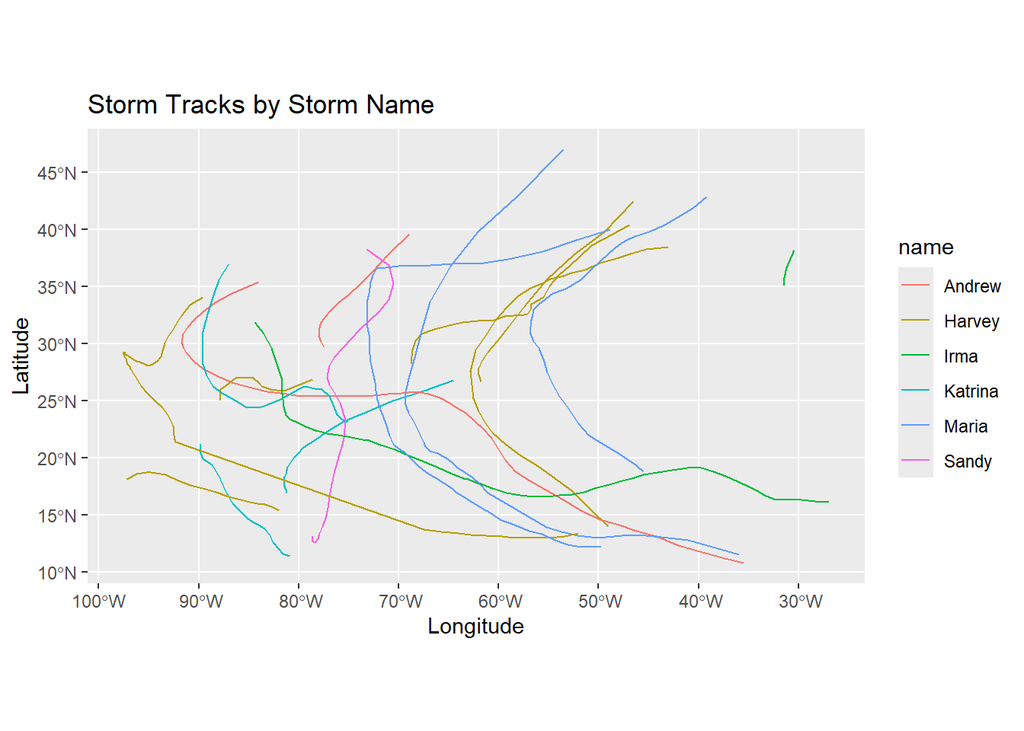

```r
# Storm tracks colored by storm name with ggplot()
storms_data.tr %>%
  ggplot(aes(color = name)) +
  geom_sf() +
  theme(legend.position = "right") +
  labs(title = "Storm Tracks by Storm Name", x = "Longitude", y = "Latitude")
```

The plot above was created with ggplot() to map the storm tracks colored by storm name.

- Red: Storm Andrew
- Brown: Storm Harvey
- Green: Storm Irma
- Light Blue: Katrina
- Dark Blue: Maria
- Pink: Sandy

> **Irma** had one of the longest tracks, originating from the far east and moved steadily to the west, and then headed northwest.

> Many of these storms originated between 10°N and 20°N latitude and east of 80°W longitude (a known zone for hurricane formation).

## Storm Tracks by Year

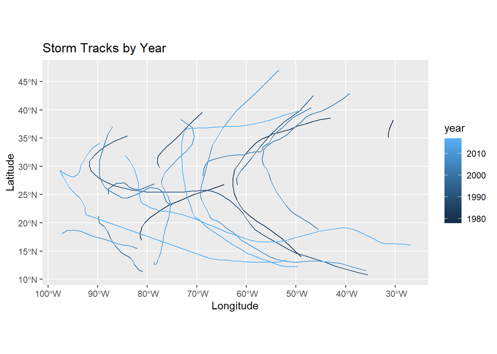

```r
# Hurricane tracks colored by year with ggplot()
storms_data.tr %>%
  ggplot(aes(color = year)) +
  geom_sf() +
  theme(legend.position = "right") + # Theme
  labs(title = "Storm Tracks by Year", x = "Longitude", y = "Latitude") # Labels
```

The plot above was created with ggplot() to map the storm tracks colored by year.

> **Harvey** formed in *1981*

> **Andrew** formed in *1992*

> **Katrina** formed in *2005*

> **Sandy** formed in *2012*

> **Irma** formed in *2017*

### Mapview of Storm Tracks by Year

```r
# Storm tracks colored by year with mapview()
mapview(storms_data.tr,
        zcol = "year", # Color tracks by name & year
        layer.name = "Year",
        popup = storms_data.tr$name, # Add hurricane name to popup
        legend = TRUE) # Add legend
```

[interactive chart not shown]

> **Maria** & **Irma** have a long path, reflecting a longer tracking period and distance

> **Sandy’s** track is known for it’s significant turn back toward land, a major contributing factor in its impact

## Storm Tracks by Wind

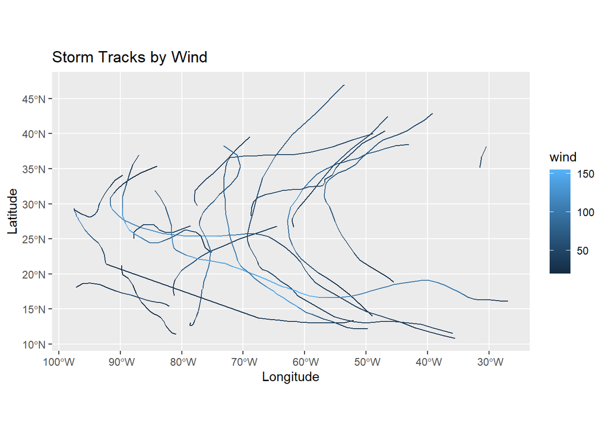

```r
# Hurricane tracks colored by wind with ggplot()
storms_data.tr2 %>%
  ggplot(aes(color = wind)) +
  geom_sf() +
  theme(legend.position = "right") +  # Theme
  labs(title = "Storm Tracks by Wind", x = "Longitude", y = "Latitude")  # Labels
```

The plot above was created with ggplot() to map the storm tracks colored by wind. The higher the wind speeds, the lighter the blue. Some of the strongest storms with wind speeds greater than 100 were around 25°N latitude and between 70°W to 80°W longitude.

> **Irma** had the *highest* wind speeds while **Sandy** had the *lowest* wind speeds

### Mapview of Storm Tracks by Wind

```r
# Map storm tracks colored by wind with mapview()
mapview(storms_data.tr2,
        zcol = "wind", # Color tracks by wind speeds
        layer.name = "Wind Speed (knots)", # Rename legend
        popup = popupTable(storms_data.tr2,
                           zcol = c("name", "year", "status", "category", "wind")), # Popup table with stats
        legend = TRUE) # Add legend
```

[interactive chart not shown]

The interactive plot above was created with mapview() to map the storm tracks colored by wind.

# Additional Analysis

## Hurricanes after 2004

```r
# Filter data to have time greater than January 1, 2004
storms_data.tr3 <- storms_data.tr2 %>%
  filter(time >= as.POSIXct("2004-01-01"))
```

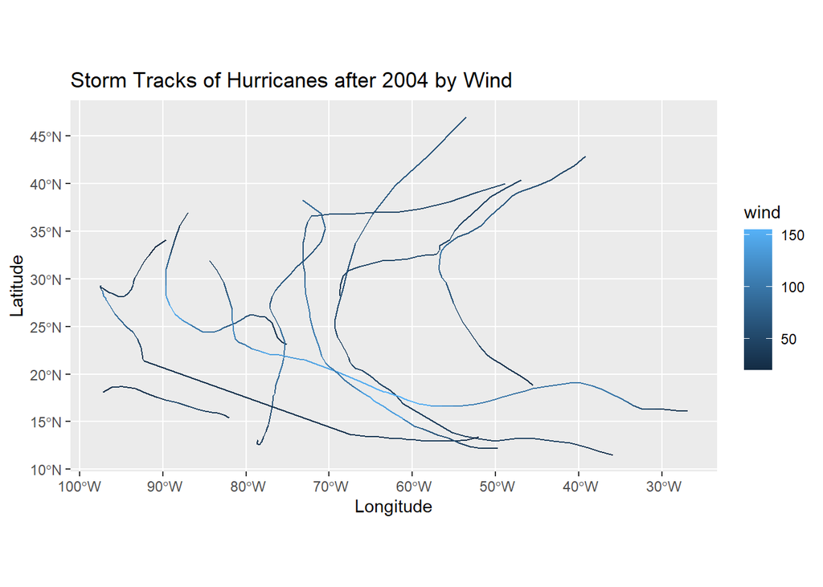

```r
# Storm tracks after 2004 colored by wind with ggplot()
storms_data.tr3 %>%
  ggplot(aes(color = wind)) +
  geom_sf() +
  theme(legend.position = "right") + # Theme
  labs(title = "Storm Tracks of Hurricanes after 2004 by Wind", x = "Longitude", y = "Latitude") # Labels
```

### Mapview of Hurricanes After 2004

```r
# Storm tracks colored by wind with mapview()
mapview(storms_data.tr3,
        zcol = "wind",
        legend = TRUE, # Add legend
        layer.name = "Wind Speed (knots)", # Rename legend
        popup = popupTable(storms_data.tr3,
                           zcol = c("name", "year", "status", "category", "wind")) # Popup table
        )
```

[interactive chart not shown]